# Reproducible Research Project 1

Sean Jackson

September 19, 2015

# Loading and preprocessing the data

**Show any code that is needed to:**

- **Load the data (i.e. read.csv())**
- **Process/transform the data (if necessary) into a format suitable for your analysis**

Load library needed to manipulate data

```r
library(Hmisc)#to extract and impute values over NA values
```

Load data from csv file

```r
temp <- unzip("activity.zip")
activity.data <- read.csv(temp, stringsAsFactors = FALSE)
```

Check data

```r
str(activity.data)
```

```
## 'data.frame':    17568 obs. of  3 variables:
##  $ steps   : int  NA NA NA NA NA NA NA NA NA NA ...
##  $ date    : chr  "2012-10-01" "2012-10-01" "2012-10-01" "2012-10-01" ...
##  $ interval: int  0 5 10 15 20 25 30 35 40 45 ...
```

Date does not have the correct class. Changing class from ‘chr’ to ‘date’

```r
activity.data$date <- as.Date(activity.data$date)
```

# What is mean total number of steps taken per day?

**For this part of the assignment, you can ignore the missing values in the dataset**

Creating a dataset with NA values removed

```r
activity.narm <- activity.data[which(!is.na(activity.data$steps)),]
```

- **Calculate the total number of steps taken per day**

```r
activity.narm.byday <- tapply(activity.narm$steps,
                              activity.narm$date,
                              sum)
activity.narm.byday
```

```
## 2012-10-02 2012-10-03 2012-10-04 2012-10-05 2012-10-06 2012-10-07
##        126      11352      12116      13294      15420      11015
## 2012-10-09 2012-10-10 2012-10-11 2012-10-12 2012-10-13 2012-10-14
##      12811       9900      10304      17382      12426      15098
## 2012-10-15 2012-10-16 2012-10-17 2012-10-18 2012-10-19 2012-10-20
##      10139      15084      13452      10056      11829      10395
## 2012-10-21 2012-10-22 2012-10-23 2012-10-24 2012-10-25 2012-10-26
##       8821      13460       8918       8355       2492       6778
## 2012-10-27 2012-10-28 2012-10-29 2012-10-30 2012-10-31 2012-11-02
##      10119      11458       5018       9819      15414      10600
## 2012-11-03 2012-11-05 2012-11-06 2012-11-07 2012-11-08 2012-11-11
##      10571      10439       8334      12883       3219      12608
## 2012-11-12 2012-11-13 2012-11-15 2012-11-16 2012-11-17 2012-11-18
##      10765       7336         41       5441      14339      15110
## 2012-11-19 2012-11-20 2012-11-21 2012-11-22 2012-11-23 2012-11-24
##       8841       4472      12787      20427      21194      14478
## 2012-11-25 2012-11-26 2012-11-27 2012-11-28 2012-11-29
##      11834      11162      13646      10183       7047
```

- **Make a histogram of the total number of steps taken each day**

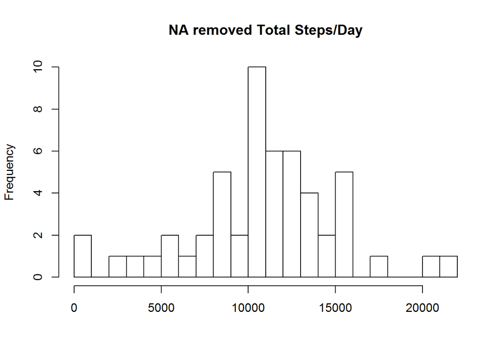

```r
hist(activity.narm.byday, 30,
     main = "NA removed Total Steps/Day",
     xlab = "")
```

- **Calculate and report the mean and median of the total number of steps taken per day**

```r
activity.narm.byday.mean <- tapply(activity.narm$steps,
                                   activity.narm$date,
                                   mean)
activity.narm.byday.mean
```

```
## 2012-10-02 2012-10-03 2012-10-04 2012-10-05 2012-10-06 2012-10-07
##  0.4375000 39.4166667 42.0694444 46.1597222 53.5416667 38.2465278
## 2012-10-09 2012-10-10 2012-10-11 2012-10-12 2012-10-13 2012-10-14
## 44.4826389 34.3750000 35.7777778 60.3541667 43.1458333 52.4236111
## 2012-10-15 2012-10-16 2012-10-17 2012-10-18 2012-10-19 2012-10-20
## 35.2048611 52.3750000 46.7083333 34.9166667 41.0729167 36.0937500
## 2012-10-21 2012-10-22 2012-10-23 2012-10-24 2012-10-25 2012-10-26
## 30.6284722 46.7361111 30.9652778 29.0104167  8.6527778 23.5347222
## 2012-10-27 2012-10-28 2012-10-29 2012-10-30 2012-10-31 2012-11-02
## 35.1354167 39.7847222 17.4236111 34.0937500 53.5208333 36.8055556
## 2012-11-03 2012-11-05 2012-11-06 2012-11-07 2012-11-08 2012-11-11
## 36.7048611 36.2465278 28.9375000 44.7326389 11.1770833 43.7777778
## 2012-11-12 2012-11-13 2012-11-15 2012-11-16 2012-11-17 2012-11-18
## 37.3784722 25.4722222  0.1423611 18.8923611 49.7881944 52.4652778
## 2012-11-19 2012-11-20 2012-11-21 2012-11-22 2012-11-23 2012-11-24
## 30.6979167 15.5277778 44.3993056 70.9270833 73.5902778 50.2708333
## 2012-11-25 2012-11-26 2012-11-27 2012-11-28 2012-11-29
## 41.0902778 38.7569444 47.3819444 35.3576389 24.4687500
```

```r
activity.narm.byday.median <- tapply(activity.narm$steps,
                                     activity.narm$date,
                                     median)
activity.narm.byday.median
```

```
## 2012-10-02 2012-10-03 2012-10-04 2012-10-05 2012-10-06 2012-10-07
##          0          0          0          0          0          0
## 2012-10-09 2012-10-10 2012-10-11 2012-10-12 2012-10-13 2012-10-14
##          0          0          0          0          0          0
## 2012-10-15 2012-10-16 2012-10-17 2012-10-18 2012-10-19 2012-10-20
##          0          0          0          0          0          0
## 2012-10-21 2012-10-22 2012-10-23 2012-10-24 2012-10-25 2012-10-26
##          0          0          0          0          0          0
## 2012-10-27 2012-10-28 2012-10-29 2012-10-30 2012-10-31 2012-11-02
##          0          0          0          0          0          0
## 2012-11-03 2012-11-05 2012-11-06 2012-11-07 2012-11-08 2012-11-11
##          0          0          0          0          0          0
## 2012-11-12 2012-11-13 2012-11-15 2012-11-16 2012-11-17 2012-11-18
##          0          0          0          0          0          0
## 2012-11-19 2012-11-20 2012-11-21 2012-11-22 2012-11-23 2012-11-24
##          0          0          0          0          0          0
## 2012-11-25 2012-11-26 2012-11-27 2012-11-28 2012-11-29
##          0          0          0          0          0
```

# What is the average daily activity pattern?

- **Make a time series plot (i.e. type = “l”) of the 5-minute interval (x-axis) and the average number of steps taken, averaged across all days (y-axis)**

[figure not shown]

- **Which 5-minute interval, on average across all the days in the dataset, contains the maximum number of steps?**

```r
activity.narm.daily[activity.narm.daily==max(activity.narm.daily)]
```

[output not shown]

```
##      835
## 206.1698
```

# Imputing missing values

Note that there are a number of days/intervals where there are missing values (coded as NA). The presence of missing days may introduce bias into some calculations or summaries of the data.

- **Calculate and report the total number of missing values in the dataset (i.e. the total number of rows with NAs)**

```r
sum(is.na(activity.data$steps))
```

```
## [1] 2304
```

- **Devise a strategy for filling in all of the missing values in the dataset. The strategy does not need to be sophisticated. For example, you could use the mean/median for that day, or the mean for that 5-minute interval, etc.**

Using Hmisc to view breakdown of NA values by interval

```r
activity.steps.Breakdown <- bystats(activity.data$steps,
                                    activity.data$interval,
                                 fun=function(x)c(Mean=mean(x),Median=median(x)))
#viewing only top for sake of brevity
activity.steps.Breakdown
```

```
##
##  c(3, 38, 3, 80, 38, 80, 3, 3) of activity.data$steps by activity.data$interval
##
##          N Missing        Mean Median
## 0       53       8   1.7169811      0
## 5       53       8   0.3396226      0
## 10      53       8   0.1320755      0
## 15      53       8   0.1509434      0
## 20      53       8   0.0754717      0
## 25      53       8   2.0943396      0
## 30      53       8   0.5283019      0
## 35      53       8   0.8679245      0
## 40      53       8   0.0000000      0
## 45      53       8   1.4716981      0
## 50      53       8   0.3018868      0
```

[output cut: 278 more lines]

Appears all instances have 8 NA values and the majority of instances have a median of 0. Instead of removing the NA values, I will impute the mean value of the non NA step instances into the NA values by creating a function

```r
impute.Mean <- function(impute.var, filter.var, var.levels){
  #for each v variable in list of inputs var.levels
  for(v in var.levels){
    #impute the median steps of each interval to the respective
    #interval with missing values in the step index
    impute.var[which(filter.var == v)] <- impute((impute.var[
      which(filter.var == v)]), fun=mean)
  }
  return(impute.var)
}
```

- **Create a new dataset that is equal to the original dataset but with the missing data filled in.** Impute missing steps with means using above function for activity data to new dataset

```r
activity.clean <- activity.data
activity.clean$steps <- impute.Mean(activity.clean$steps,            #steps
                                     activity.clean$interval,          #intervals
                                     unique(activity.clean$interval))  #unique interval values
```

Check steps for NA values

```r
sum(is.na(activity.clean$steps))
```

```
## [1] 0
```

- **Make a histogram of the total number of steps taken each day and Calculate and report the mean and median total number of steps taken per day. Do these values differ from the estimates from the first part of the assignment? What is the impact of imputing missing data on the estimates of the total daily number of steps?**

Now that the NA values have been imputed, create a variable of the divided up daily data using tapply and create a histogram of data

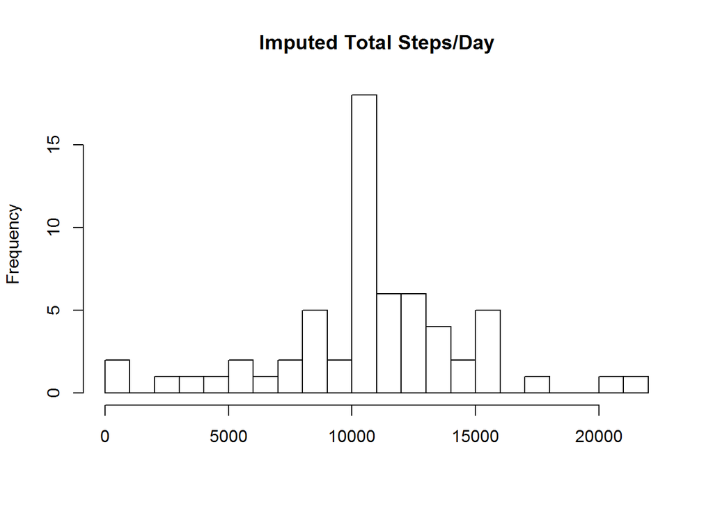

```r
activity.clean.byday <- tapply(activity.clean$steps,
                               activity.clean$date,
                               sum)
hist(activity.clean.byday, 30,
     main = "Imputed Total Steps/Day",
     xlab = "")
```

```r
mean(activity.clean.byday)
```

```
## [1] 10766.19
```

```r
median(activity.clean.byday)
```

```
## [1] 10766.19
```

# Are there differences in activity patterns between weekdays and weekends?

**For this part the weekdays() function may be of some help here. Use the dataset with the filled-in missing values for this part.**

- **Create a new factor variable in the dataset with two levels - “weekday” and “weekend” indicating whether a given date is a weekday or weekend day.**

```r
#create variable for day of week using weekdays function on date index
activity.clean$day<-weekdays(activity.clean$date)
#create weekend/weekday variable
activity.clean$weekday.weekend<- as.factor(c("weekend", "weekday"))
#populate weekend/weekday variable based on is or is not saturday/sunday
activity.clean[activity.clean$day == "Sunday" | activity.clean$day == "Saturday" ,5]<- factor("weekend")
activity.clean[!(activity.clean$day == "Sunday" | activity.clean$day == "Saturday"),5 ]<- factor("weekday")
```

- **Make a panel plot containing a time series plot (i.e. type = “l”) of the 5-minute interval (x-axis) and the average number of steps taken, averaged across all weekday days or weekend days (y-axis). See the README file in the GitHub repository to see an example of what this plot should look like using simulated data.**

```r
#create dataset of weekend and weekday data respectively
activity.data.weekend <- subset(activity.clean,
                                weekday.weekend == "weekend")
activity.data.weekday <- subset(activity.clean,
                                weekday.weekend == "weekday")

#create datasets for weekdays and weekend of the mean daily usage
activity.weekend.daily <- tapply(activity.data.weekend$steps,
                                 activity.data.weekend$interval,
                                 mean)
activity.weekday.daily <- tapply(activity.data.weekday$steps,
                                 activity.data.weekday$interval,
                                 mean)
```

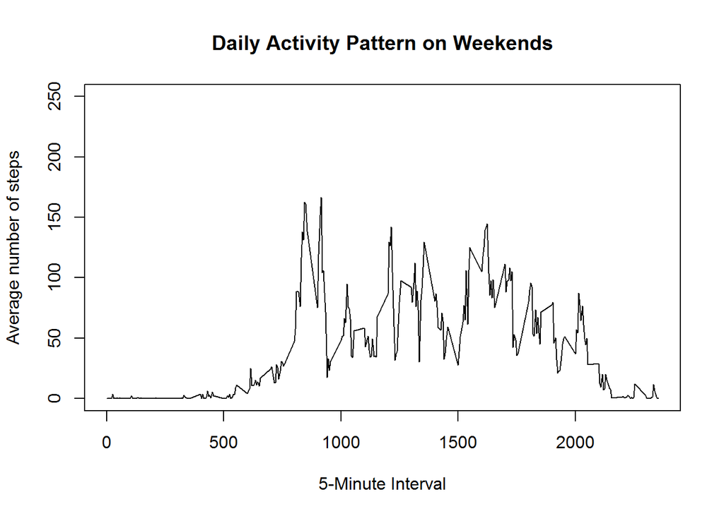

```r
#plot the datasets
plot(y = activity.weekend.daily, x = names(activity.weekend.daily),
     type = "l", xlab = "5-Minute Interval",
     main = "Daily Activity Pattern on Weekends",
     ylab = "Average number of steps",
     ylim =c(0, 250))
```

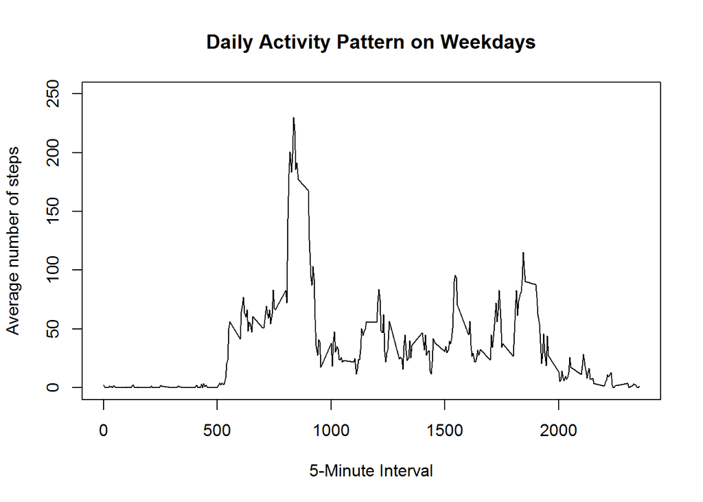

```r
plot(y = activity.weekday.daily, x = names(activity.weekday.daily),
     type = "l", xlab = "5-Minute Interval",
     main = "Daily Activity Pattern on Weekdays",
     ylab = "Average number of steps",
     ylim =c(0, 250))
```